# Mathematical Programming/Optimization, Part 2

PSTAT 134 (Winter 2026)

Author

Affiliation

Sang-Yun Oh

University of California, Santa Barbara

# Example Optimization Problem: Internet Ads

## Problem formulation for Internet Ads

Suppose we are an advertising agency and want to optimize ad scheduling over $T$ time slots.

- Ads/advertisers: $a=1, \ldots, A$ (total of $A$ ads)
- Timeslots: $t=1, \ldots, T$ (up to $T$ time slots)
- Site visitors: $v_t$ in time slot $t$
- Ads displayed: $d_{at} \geq 0$ is ad $a$ displayed in period $t$.

. . .

Our constraints are

- Visitor constraint: $\sum_a d_{at} \leq v_t$ (at most $v_t$ displays)
- Contractual constraint: $\sum_t d_{at} \geq c_a$ (at least $c_a$ displays).
- Our goal is to choose $d_{at}$.

## Clicks and revenue

- Number of clicks: $k_{at}$ on ad $a$ in period $t$.
- Click model: $k_{at} = p_{at}d_{at}$, where
- Click probability: $p_{at} \in [0,1]$ is for ad $a$ in time $t$.
- Ad revenue: $s_a$ from ad $a$, where one click pays $r_a$, up to budget $b_a$.
  $$s_a = \min \left\{ r_a \sum_t k_{at}, b_a\right\}= \min \left\{ r_a \sum_t p_{at}d_{at}, b_a\right\},$$
- What do we want to optimize?
- What shape is $s_a$ as a function of $d_{at}$?

## Define Ad Optimization Problem

- Objective: maximize total revenue: $\sum_a s_a$, where $s_a = \min \left\{ r_a \sum_t k_{at}, b_a\right\}$.
- Decision variables: $d_{at}$ for all $a$ and $t$.
- Constraints:
  - Non-negativity: $d_{at} \geq 0$ for all $a$ and $t$.
  - Visitor limit: $\sum_a d_{at} \leq v_t$ for all $t$.
  - Contractual obligations: $\sum_t d_{at} \geq c_a$ for all $a$.
- Parameters:
  - $c_a$, $r_a$, $b_a$: contracted impr, revenue per click, and budget for ad $a$.
  - $p_{at}$: click probability for ad $a$ in time $t$.
  - $v_t$: number of visitors in time slot $t$.

## Ad optimization

We choose displays $d_{at}$ to maximize revenue, i.e., we solve

$$\begin{array}{ll}
\operatorname{maximize}_{d_{at}} & \sum_a s_a \\
\mbox{subject to} & d_{at} \geq 0 \quad \text{(non-negative displays)} \\
& \sum_a d_{at} \leq v_t \quad \text{(limited visitors to site)} \\
& \sum_t d_{at} \geq c_a \quad \text{(contractual obligations)}
\end{array}$$

## Generate synthetic data

Generate synthetic data for ad optimization problem:

**Advertisers and Website data generation**

```python
import numpy as np

np.random.seed(30)
A = 3  # Number of ads
T = 24  # Number of time slots
SCALE = 10000

## Website visitors and ad parameters

# Probability of click: p_{at} ∈ R^{AxT}
P = 0.05 * np.random.uniform(size=(A, T))

# Visitors over time: v_t ∈ R^T
v = np.sin(np.linspace(-2 * np.pi / 2, 2 * np.pi - 2 * np.pi / 2, T)) * SCALE
v += -np.min(v) + SCALE

## Ad parameters: b_a, c_a, r_a for all ads a

# Budget for ads: b_a
b = np.random.lognormal(mean=8, size=(A,)) + 10000
b = 1000 * np.round(b / 1000)

# Contracted impressions: c_a ∈ R^A
c = np.random.uniform(size=A)
c *= 0.9 * v.sum() / c.sum()
c = 1000 * np.round(c / 1000)

# Revenue per click: r_a ∈ R^A
r = np.random.lognormal(mean=0.0, sigma=0.5, size=A)
```

|  | 0 | 1 | 2 |
| --- | --- | --- | --- |
| $b_a$ (budget) | 11000 | 13000 | 11000 |
| $c_a$ (contracted impr) | 170000 | 162000 | 100000 |
| $r_a$ (revenue per click) | 0.537 | 0.955 | 1.051 |

## Generated website traffic data

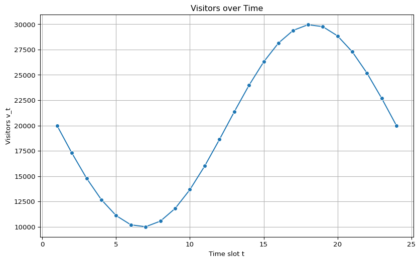

## Solve Optimization Problem

**Solve the ad optimization problem**

```python
# Form and solve the optimal advertising problem (maximize sum_a s_a)
import cvxpy as cp

D = cp.Variable((A, T))  # D_{a,t}
s = []
for a in range(A):
    clicks_a = cp.sum(cp.multiply(P[a, :], D[a, :]))  # ∑_t p_{a,t} d_{a,t}
    s.append(cp.minimum(r[a] * clicks_a, b[a]))       # s_a = min{ r_a * clicks_a, b_a }

prob = cp.Problem(
    cp.Maximize(cp.sum(s)),
    [
        D >= 0,                              # non-negative displays
        cp.sum(D, axis=0) <= v,              # ∑_a d_{a,t} ≤ v_t
        cp.sum(D, axis=1) >= c,              # ∑_t d_{a,t} ≥ c_a
    ],
)
prob.solve();
```

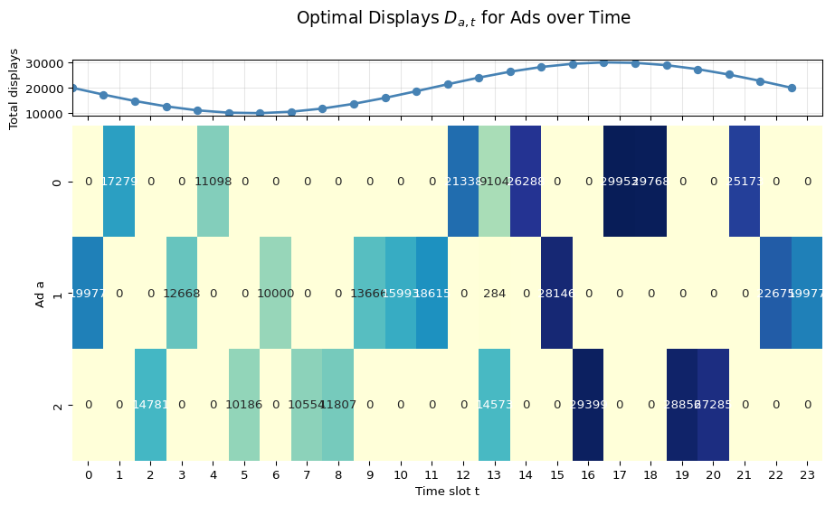

## Check Constraints and Total Revenue

**Check if the solution satisfies the constraints**

```python
# Check constraints
displays = D.value
print("Check non-negative displays (D >= 0):", np.all(displays >= 0))
print("Check limited visitors to site (∑_a d_{a,t} ≤ v):", np.all(displays.sum(axis=0) <= v + 1e-5))
print("Check contractual obligations (∑_t d_{a,t} ≥ c):", np.all(displays.sum(axis=1) >= c - 1e-5))
print("Check if total revenue is within budgets:", all(
    r[a] * (P[a, :] @ displays[a, :]) <= b[a] + 1e-5 for a in range(A)
))
```

```
Check non-negative displays (D >= 0): True
Check limited visitors to site (∑_a d_{a,t} ≤ v): True
Check contractual obligations (∑_t d_{a,t} ≥ c): True
Check if total revenue is within budgets: True
```

. . .

**Total revenue achieved by the optimal solution**

```python
total_revenue = prob.value
print("Total Revenue Achieved: $", round(total_revenue, 2))
```

```
Total Revenue Achieved: $ 13514.0
```

# Optimization Algorithms: Gradient Descent

## Direction of Function Decrease

Find $x^*$ that minimize function $f(x)$:
$$x^* = \arg\min_x f(x).$$

- Starting at $x=a$, is minimum to left or right?
- Starting at $x=a$, does $f(x)$ *decreases* to left or right?
- Repeatedly decrease $f(x)$ by adjusting $x$
- When $f(x)$ stops decreasing ($x$ converges to a point), stop
- **How to determine the direction of function decrease?**

## Univariate Convex Function

**Convex Function**

Differentiable convex function $g(x)$ satisfies
$$g(x) \geq g(a) + g'(a)(x-a),$$
for any valid $x$ and $a$ in $\mathbb{R}$.

. . .

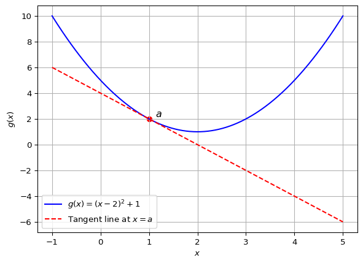

Convex function $g(x) = (x-2)^2 + 1$ and its tangent line at $x=a$

## Descent Direction

**Convex Function**

Differentiable convex function $g(x)$ satisfies
$$g(x) \geq g(a) + g'(a)(x-a),$$
for any valid $x$ and $a$ in $\mathbb{R}$.

- Starting at point $a$, find $b$ decreases $f$: i.e.,
  $$f(a) - f(b) \geq 0$$
- For a convex function $f$, show that $b$ satisfies
  $$f'(a)(b-a) \leq 0$$

## Example: Univariate Quadratic Function

How do you satisfy $f^{\prime}(a)(b-a)\leq 0$?

- Case 1: if slope $f'(a)<0$, we need $b>a$: i.e. move right.
- Case 2: if slope is $f'(a)>0$, we need $b<a$: i.e. move left
- Case 3: if slope is $f'(a)=0$, we are at the minimum

. . .

**Iterative algorithm to find minimum**:

- $b \leftarrow a - f'(a)$ is a possibility, but could overshoot!
- A small enough step size (aka learning rate) $\alpha$ works:
  $$b \leftarrow a - \alpha\cdot f'(a)$$

## Example 1: Univariate Quadratic Function

```python
def f(x): return (x+1)**2
def fprime(x): return 2*(x+1)

def find_minimum_1(func, slope, a = 2, step=0.1, max_iter=1000):

    for i in range(0, max_iter):

        # find next target point
        b = a - step*slope(a)

        # set target point as the new starting point
        a = b

    return b

x = np.linspace(-10, 10, num=1000)
xstar = find_minimum_1(f, fprime)

print('  xstar  = %f, f(xstar) = %f' % (xstar, f(xstar)))
```

```
  xstar  = -1.000000, f(xstar) = 0.000000
```

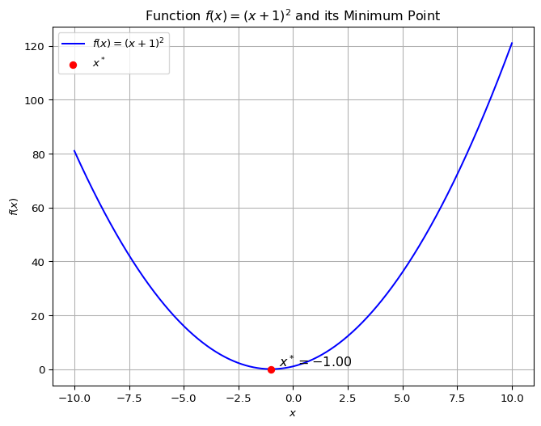

Function $f(x) = (x+1)^2$ and its minimum point

## Example 2: Univariate Quadratic Function

```python
def g(x): return (x-3.2)**2 - x + 2.3
def gprime(x): return 2*(x-3.2) - 1

x = np.linspace(-3, 8, num=1000)
xstar = find_minimum_1(g, gprime)

print('  xstar  = %f, g(xstar) = %f' % (xstar, g(xstar)))
```

```
  xstar  = 3.700000, g(xstar) = -1.150000
```

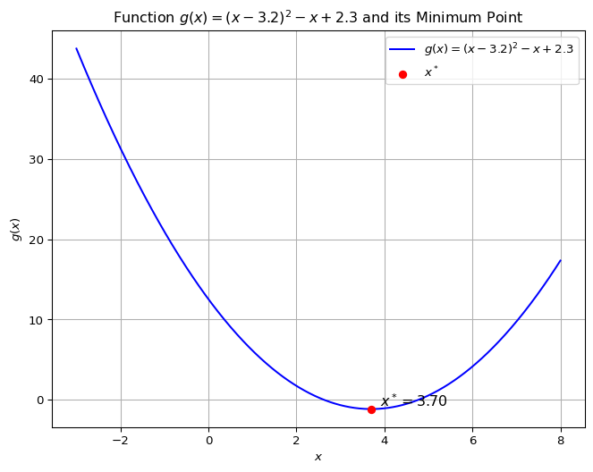

Function $g(x) = (x-3.2)^2 - x + 2.3$ and its minimum point

## Improving Optimization Algorithm

```python
def find_minimum_2(func, slope, x0 = 2, rate=0.1, message=False):

    assert(rate > 0 and rate < 1)

    c = 0
    for i in range(0, 1000):

        # find next target point
        x1 = x0 - rate*slope(x0)

        if np.isclose(x1, x0, rtol=1e-5):
            if message:
                print('converged in %d iterations' % c)
            return x1

        if func(x1) < func(x0): # func decreased
            x0 = x1
            c += 1
        else:                   # func did not decrease
            rate *= rate        # reduce step size

    print('warning: algorithm did not converge')

    return x1

xstar = find_minimum_2(g, gprime, message=True) ## less number of loops
g(xstar)
```

```
converged in 41 iterations
```

```
-1.1499999790850541
```

## Complexity vs. Running time

Algorithm complexity and running times are different concepts:

```python
%timeit -n10 -r10 find_minimum_1(g, gprime) ## faster running time

%timeit -n10 -r10 find_minimum_2(g, gprime) ## slower running time
```

```
77.8 μs ± 1.66 μs per loop (mean ± std. dev. of 10 runs, 10 loops each)
405 μs ± 5.28 μs per loop (mean ± std. dev. of 10 runs, 10 loops each)
```

## Multivariate Convex Function

**First-Order Convexity Condition**

Let $f: D \rightarrow \mathbb{R}$ be continuously differentiable, where $D \subseteq \mathbb{R}^d$ is convex. Then $f$ is convex over $D$ if and only if

$$f(\mathbf{y}) \geq f(\mathbf{x})+\nabla f(\mathbf{x})^T(\mathbf{y}-\mathbf{x}), \quad \forall \mathbf{x}, \mathbf{y} \in D$$

Note that the right-hand side is the linear approximation to $f$ at $\mathbf{x}$ from Taylor’s Theorem without the remainder.

. . .

**Descent Direction and Directional Derivative**

Let $f: \mathbb{R}^d \rightarrow \mathbb{R}$ be continuously differentiable at $\mathbf{x}_0$. A vector $\mathbf{v}$ is a descent direction for $f$ at $\mathbf{x}_0$ if

$$\frac{\partial f\left(\mathbf{x}_0\right)}{\partial \mathbf{v}}=\nabla f\left(\mathbf{x}_0\right)^T \mathbf{v}<0$$

that is, if the directional derivative of $f$ at $\mathbf{x}_0$ in the direction $\mathbf{v}$ is negative.

## Directional Derivative and Gradient

**Directional Derivative and Gradient**

Let $f: D \rightarrow \mathbb{R}$ where $D \subseteq \mathbb{R}^d$, let $\mathbf{x}_0 \in D$ be an interior point of $D$ and let $\mathbf{v} \in \mathbb{R}^d$ be a vector. Assuming $f$ is continuously differentiable at $\mathbf{x}_0$, the directional derivative of $f$ at $\mathbf{x}_0$ in direction $\mathbf{v}$ is

$$\frac{\partial f\left(\mathbf{x}_0\right)}{\partial \mathbf{v}}=\nabla f\left(\mathbf{x}_0\right)^T \mathbf{v}$$

. . .

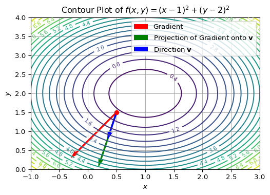

Contour plot of $f(x, y) = (x-1)^2 + (y-2)^2$

## Gradient Descent Algorithm

**Direction of Steepest Descent**

Let $f: \mathbb{R}^d \rightarrow \mathbb{R}$ be continuously differentiable at $\mathbf{x}_0$. For any unit vector $\mathbf{v} \in \mathbb{R}^d$,

$$\frac{\partial f\left(\mathbf{x}_0\right)}{\partial \mathbf{v}} \geq \frac{\partial f\left(\mathbf{x}_0\right)}{\partial \mathbf{v}^*}$$

where

$$\mathbf{v}^*=-\frac{\nabla f\left(\mathbf{x}_0\right)}{\left\|\nabla f\left(\mathbf{x}_0\right)\right\|}$$

. . .

**Gradient Descent Algorithm**

Each iteration of gradient descent takes a step in the direction of the negative of the gradient:

$$\mathbf{x}^{t+1}=\mathbf{x}^t-\alpha_t \nabla f\left(\mathbf{x}^t\right), \quad t=0,1,2 \ldots$$

for a sequence of step sizes $\alpha_t>0$. The algorithm is initialized with an initial guess $\mathbf{x}^0$.

## Example: Lasso Regression

The lasso can be written in Lagrangian (unconstrained) form as:

$$\operatorname{minimize}_{\boldsymbol{\beta}} \quad \frac{1}{2}\|\mathbf{y} - \mathbf{X}\boldsymbol{\beta}\|_2^2 + \lambda \|\boldsymbol{\beta}\|_1$$

where $\mathbf{y} \in \mathbb{R}^n$ is response, $\mathbf{X} \in \mathbb{R}^{n \times p}$ is design matrix, $\boldsymbol{\beta} \in \mathbb{R}^p$ are coefficients, and $\lambda \geq 0$ is regularization parameter.

. . .

In constrained form,
$$\begin{array}{ll}
\operatorname{minimize}_{\boldsymbol{\beta}} & \frac{1}{2}\|\mathbf{y} - \mathbf{X}\boldsymbol{\beta}\|_2^2 \\
\text{subject to} & \|\boldsymbol{\beta}\|_1 \leq s
\end{array},$$

where $s \geq 0$ controls the amount of regularization.

## Example: Lasso Regression Feasible Region

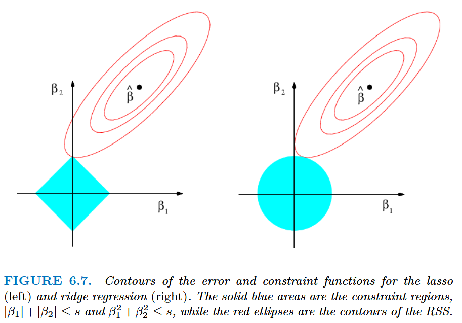

Image: Introduction to Statistical Learning in Python

## Other Types of Optimization Problems

- Mixed Integer Programming (MIP): some variables constrained to be integers.
- Quadratic Programming (QP): objective function is quadratic, constraints linear.
- Second-Order Cone Programming (SOCP): constraints include second-order (quadratic) cones
- Semidefinite Programming (SDP): constraints include positive semidefinite matrices.
- Exponential and Power Cone Programming: constraints include exponential or power cones.

## Libraries and Types of Optimization Problems

|  | LP | QP | SOCP | SDP | EXP | POW | MIP |
| --- | --- | --- | --- | --- | --- | --- | --- |
| [CBC](https://projects.coin-or.org/Cbc) | X |  |  |  |  |  | X |
| [CLARABEL](https://oxfordcontrol.github.io/ClarabelDocs/) | X | X | X | X | X | X |  |
| [COPT](https://github.com/COPT-Public/COPT-Release) | X | X | X | X | X |  | X** |
| [DAQP](https://darnstrom.github.io/daqp/) | X | X |  |  |  |  |  |
| [GLOP](https://developers.google.com/optimization) | X |  |  |  |  |  |  |
| [GLPK](https://www.gnu.org/software/glpk/) | X |  |  |  |  |  |  |
| [GLPK_MI](https://www.gnu.org/software/glpk/) | X |  |  |  |  |  | X |
| [OSQP](https://osqp.org/) | X | X |  |  |  |  |  |
| [PIQP](https://predict-epfl.github.io/piqp/) | X | X |  |  |  |  |  |
| [PROXQP](https://github.com/simple-robotics/proxsuite) | X | X |  |  |  |  |  |
| [PDLP](https://developers.google.com/optimization) | X |  |  |  |  |  |  |
| [QOCO](https://qoco-org.github.io/qoco/) | X | X | X |  |  |  |  |
| [CPLEX](https://www.ibm.com/docs/en/icos) | X | X | X |  |  |  | X |
| [NAG](https://nag.com/mathematical-optimization/) | X | x | X |  |  |  |  |

|  | LP | QP | SOCP | SDP | EXP | POW | MIP |
| --- | --- | --- | --- | --- | --- | --- | --- |
| ECOS | X | X | X |  | X |  |  |
| [GUROBI](https://www.gurobi.com/) | X | X | X |  |  |  | X |
| [MOSEK](https://www.mosek.com/) | X | X | X | X | X | X | X** |
| MPAX | X | X |  |  |  |  |  |
| [CUCLARABEL](https://github.com/cvxgrp/CuClarabel) | X | X | X |  | X | X |  |
| [CUOPT](https://github.com/NVIDIA/cuopt) | X |  |  |  |  |  | X* |
| [CVXOPT](http://cvxopt.org/) | X | X | X | X |  |  |  |
| [SDPA](https://sdpa-python.github.io) *** | X | X | X | X |  |  |  |
| [SCS](http://github.com/cvxgrp/scs) | X | X | X | X | X | X |  |
| [SCIP](https://scip.zib.de/) | X | X | X |  |  |  | X |
| [XPRESS](https://www.fico.com/en/products/fico-xpress-optimization) | X | X | X |  |  |  | X |
| [SCIPY](https://docs.scipy.org/doc/scipy/reference/generated/scipy.optimize.linprog.html#scipy.optimize.linprog) | X |  |  |  |  |  | X* |
| [HiGHS](https://highs.dev/) | X | X |  |  |  |  | X* |

When installed, these libraries can be interfaced with Python via [CVXPY](https://www.cvxpy.org/tutorial/solvers/index.html).